# Table of Contents

大家阅读下面kernel的时候,建议大家安装jupyter extension，这样方便看到目录等。

# 导入工具包 & 读取数据

```python
import pandas as pd
import numpy as np
import lightgbm as lgb
import seaborn as sns
import keras
import tensorflow as tf
import matplotlib.pyplot as plt
from sklearn.metrics import log_loss
from sklearn.preprocessing import LabelEncoder
%matplotlib inline
```

```python
train = pd.read_csv('/data/Data_JieZhang/Xunfei/round1_iflyad_train.txt',sep='\t')
test = pd.read_csv('/data/Data_JieZhang/Xunfei/round1_iflyad_test_feature.txt',sep='\t')
```

# 数据准备

```python
# data = pd.concat([train,test],ignore_index=True)
data = train.copy()
```

```python
data = data.sort_values('time')
```

# 数据探索分析(EDA)

数据探索一般分为全局和局部两种.

全局数据分析重点在于了解数据的大致情况，包括数据的格式，不同的格式的处理方式往往存在非常大的差异，如果全局数据分析差不多的时候我们便可以开始一步步的对数据进行局部分析，局部分析往往是单变量以及多变量与标签的关系分析亦或者是变量之间的分析。

此处我们就简单的分析一下,里面还有部分全局的和局部的分析。

```python
data.head()
```

|  | instance_id | time | city | province | user_tags | carrier | devtype | make | model | nnt | ... | creative_width | creative_height | creative_is_jump | creative_is_download | creative_is_js | creative_is_voicead | creative_has_deeplink | app_paid | advert_name | click |
| --- | --- | --- | --- | --- | --- | --- | --- | --- | --- | --- | --- | --- | --- | --- | --- | --- | --- | --- | --- | --- | --- |
| 874185 | 4871560165930991338 | 2190038403 | 137106105106100 | 137106105100100 | 3003779,3003779,3003843,3003851,3003863,300386... | 3 | 2 | vivo | vivo X20 | 4 | ... | 960 | 640 | True | False | False | False | False | False | B4734117F35EE97F | 0 |
| 932291 | 1156288606795451147 | 2190038408 | 137101105106100 | 137101105100100 | 3003779,3003843,3003845,3003851,3003863,300387... | 2 | 2 | vivo | vivo+Y79A | 4 | ... | 960 | 640 | True | False | False | False | False | False | B4734117F35EE97F | 0 |
| 731 | 2886794733240524743 | 2190038409 | 137104102106100 | 137104102100100 | NaN | 1 | 2 | Apple | iPhone 5s (Global) | 3 | ... | 320 | 480 | True | False | False | False | False | False | 310405E93895BD58 | 0 |
| 874289 | 2117825034610349718 | 2190038409 | 137104104106100 | 137104104100100 | 2100041,2100042,2100030,2100198,2100265,210002... | 1 | 2 | OPPO | OPPO%252BR9tm | 4 | ... | 100 | 640 | True | False | False | False | False | False | 862FF2E9B0AD4C14 | 0 |
| 26991 | 5597056059236856846 | 2190038409 | 137105102117100 | 137105102100100 | 3003273,3003339,3003379,3003537,3003559,300371... | 1 | 2 | vivo | vivo Y67 | 1 | ... | 300 | 300 | True | False | False | False | False | False | 310405E93895BD58 | 0 |

5 rows × 35 columns

## 数据类别分布(nunique)

我们先看数据的nunique情况，看这个我们主要确定是否采用one-hot以及删除某些特征(主要是所有行和列都一样的),通过下面的分析,我们发现creative_is_js， creative_is_voicead，app_paid这些都是可以直接删除的，因为他们只有一个值，模型几乎学不到任何东西(也可以通过绘制模型的特征重要性,这些特征一般重要性为0)

```python
data.nunique()
```

```
instance_id              1001650
time                      443670
city                         333
province                      35
user_tags                 464200
carrier                        4
devtype                        4
make                        3140
model                      14053
nnt                            6
os                             3
osv                          300
os_name                        3
adid                        2079
advert_id                     38
orderid                      936
advert_industry_inner         24
campaign_id                   64
creative_id                  862
creative_tp_dnf               40
app_cate_id                   22
f_channel                     73
app_id                       438
inner_slot_id               1169
creative_type                  5
creative_width                20
creative_height               13
creative_is_jump               2
creative_is_download           2
creative_is_js                 1
creative_is_voicead            1
creative_has_deeplink          2
app_paid                       1
advert_name                   34
click                          2
dtype: int64
```

```python
data.drop('creative_is_voicead',axis=1,inplace = True)
data.drop('app_paid',axis=1,inplace=True)
data.drop('creative_is_js',axis=1,inplace=True)
```

### 小的nunique数据处理

通过上面观察,还有一些特征是可以手工处理的，例如那些nunique个数为2的特征，我们可以看看这些特征的基础情况

#### creative_is_jump特征

我们发现creative_is_jump是一个极为重要的特征,当它为False的时候,它的点击率极低,是个不错的特征

```python
data.groupby('creative_is_jump')['click'].agg({'mean','count'})
```

| creative_is_jump | count | mean |
| --- | --- | --- |
| False | 19111 | 0.010413 |
| True | 982539 | 0.202117 |

#### creative_is_download特征

我们发现creative_is_download是一个极为重要的特征,当它为True的时候,它的点击率极低,是个不错的特征

```python
data.groupby('creative_is_download')['click'].agg({'mean','count'})
```

| creative_is_download | count | mean |
| --- | --- | --- |
| False | 982539 | 0.202117 |
| True | 19111 | 0.010413 |

#### creative_has_deeplink特征

我们发现creative_has_deeplink是一个极为重要的特征,当它为True的时候,它的点击率也很低,是个不错的特征

```python
data.groupby('creative_has_deeplink')['click'].agg({'mean','count'})
```

| creative_has_deeplink | count | mean |
| --- | --- | --- |
| False | 1001352 | 0.198504 |
| True | 298 | 0.050336 |

### 相同nunique特征分析

我们发现有些特征是nunique是相同的，在处理此类特征时，我们往往会观察一下，这两个特征是否存在交叉关系，如果不存在交叉关系，那么我们只需要保存一个即可。

#### os & os_name

我们发现os和os_name是不存在交叉关系的,这边我们用简单的groupby操作来看,也可以用scipy的spearson函数来判断单调性进行观察，所以我们可以没有顾虑的删除其中的任意一个,这边我们删除os_name。

```python
data.groupby('os_name')['os'].agg({'nunique'})
```

| os_name | nunique |
| --- | --- |
| android | 1 |
| ios | 1 |
| unknown | 1 |

```python
data.groupby('os')['os_name'].agg({'nunique'})
```

| os | nunique |
| --- | --- |
| 0 | 1 |
| 1 | 1 |
| 2 | 1 |

```python
data.drop('os_name',axis=1,inplace=True)
```

其他的大家可以自行去看，此处不做更多篇幅细细描述。

## Time分析

所有的问题,涉及到时间最好对时间进行细细的分析,正如开始我们将数据按照time进行排序一般,此处我们来细细的观察一下time特征。

在推荐系统或者其他的系统中，不同时间段用户的行为是不一样的，尤其是晚上大家都睡着了就没什么人看广告什么的了。

通过下面简单的分析,我们可以猜测我们的训练集是7天的，虽然不是很清楚具体的时间，但是我们看时间主要看的是周期性，毕竟很多时候我们会选择基于树的模型，所以我们只要能找到周期性的时间表示即可.

```python
data['time'].max() - data['time'].min()
```

```
604676
```

```python
604676 / 24 / 3600
```

```
6.998564814814815
```

### 周期性时间提取

```python
data_time_min = data['time'].min()
data['day'] = (data['time'].values - data_time_min) / 3600 / 24
data['day'] = data['day'].astype(int)
data['hour'] = (data['time'].values - data_time_min - data['day'].values * 3600 * 24) / 3600
data['hour'] = data['hour'].astype(int)
```

### Hour周期性观察

我们随机的看两天，我们发现在时间为0或者1的时候点击率非常低,而且随着时间的增长点击率呈现轻微的上升趋势,这也就验证了我们之前的猜想。

```python
data.loc[data.day == 0].groupby('hour')['click'].agg({'mean','count'})
```

| hour | count | mean |
| --- | --- | --- |
| 0 | 6623 | 0.077608 |
| 1 | 2552 | 0.099530 |
| 2 | 1370 | 0.115328 |
| 3 | 1076 | 0.114312 |
| 4 | 1205 | 0.140249 |
| 5 | 2280 | 0.166228 |
| 6 | 3602 | 0.184342 |
| 7 | 4639 | 0.206079 |
| 8 | 5409 | 0.206323 |
| 9 | 5922 | 0.200101 |
| 10 | 6277 | 0.205034 |
| 11 | 6280 | 0.199045 |
| 12 | 6499 | 0.192030 |
| 13 | 5900 | 0.197797 |
| 14 | 5607 | 0.201355 |
| 15 | 9009 | 0.162393 |
| 16 | 7428 | 0.212170 |
| 17 | 7561 | 0.230657 |
| 18 | 7987 | 0.203581 |
| 19 | 7761 | 0.212473 |
| 20 | 8262 | 0.213266 |
| 21 | 8372 | 0.217511 |
| 22 | 8080 | 0.213119 |
| 23 | 5790 | 0.213299 |

```python
data.loc[data.day == 1].groupby('hour')['click'].agg({'mean','count'})
```

| hour | count | mean |
| --- | --- | --- |
| 0 | 5403 | 0.068295 |
| 1 | 2705 | 0.093530 |
| 2 | 1534 | 0.107562 |
| 3 | 1128 | 0.116135 |
| 4 | 1134 | 0.145503 |
| 5 | 1969 | 0.169121 |
| 6 | 3357 | 0.193625 |
| 7 | 5220 | 0.205364 |
| 8 | 6879 | 0.226196 |
| 9 | 6792 | 0.222615 |
| 10 | 7446 | 0.214343 |
| 11 | 7877 | 0.211502 |
| 12 | 8281 | 0.202874 |
| 13 | 7664 | 0.204462 |
| 14 | 7213 | 0.207958 |
| 15 | 7649 | 0.201987 |
| 16 | 7224 | 0.207364 |
| 17 | 7474 | 0.208857 |
| 18 | 7467 | 0.211732 |
| 19 | 7344 | 0.206155 |
| 20 | 8398 | 0.205763 |
| 21 | 8917 | 0.199170 |
| 22 | 7884 | 0.195332 |
| 23 | 5775 | 0.197229 |

此处图片我就不细细的绘制了，大家凑活着看吧......

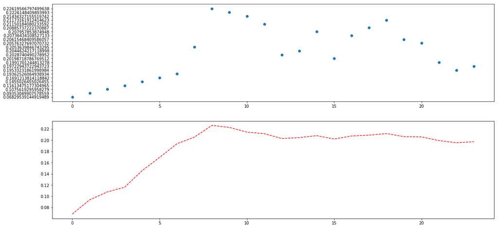

```python
fig, ax = plt.subplots(nrows=2, ncols=1,figsize=[20,10])
ax[0].scatter(x = range(24), y=data.loc[data.day == 1].groupby('hour')['click'].agg({'mean'}))
ax[1].plot( data.loc[data.day == 1].groupby('hour')['click'].agg({'mean'}),'r--')
```

### Day的观察

我们发现每天的数据是类似的，除了5,6,那两天好像是周末,所以count比较大,但是平均的点击率并没有太大的区别,应该是主办方通过某种采样得到的数据。

```python
data.groupby('day')['click'].agg({'mean','count'})
```

| day | count | mean |
| --- | --- | --- |
| 0 | 135491 | 0.193349 |
| 1 | 142734 | 0.196849 |
| 2 | 145163 | 0.197275 |
| 3 | 129063 | 0.194424 |
| 4 | 140688 | 0.203209 |
| 5 | 151301 | 0.195689 |
| 6 | 157210 | 0.207150 |

## Object特征分析

```python
object_cols = [col for col in data.columns if data[col].dtypes == 'O']
object_cols
```

```
['user_tags',
 'make',
 'model',
 'osv',
 'advert_industry_inner',
 'f_channel',
 'inner_slot_id',
 'advert_name']
```

```python
data[object_cols].head(20)
```

[output not shown]

### advert_industry_inner特征

按照官方说的,这个特征有两个部分,一般这种特征的话大家常见的操作有三个，一个是split展开，第二个是统计后半部分的出现次数,count,第三个就是统计后半部分出现次数占整个类的比例。

```python
data['advert_industry_inner_first'] = data['advert_industry_inner'].apply(lambda x:x.split('_')[0])
data['advert_industry_inner_second'] = data['advert_industry_inner'].apply(lambda x:x.split('_')[1])
data.drop('advert_industry_inner',axis=1,inplace=True)
```

- 我们发现这个特征也是一个非常好的 特征，放我们的advert_industry_inner_first = 9的时候,点击率为0,还有很多远离了我们的click均值,是一个不错的特征

```python
data.groupby('advert_industry_inner_first')['click'].agg({'count','mean'})
```

| advert_industry_inner_first | count | mean |
| --- | --- | --- |
| 100300 | 20476 | 0.040779 |
| 100600 | 7558 | 0.028314 |
| 101000 | 58797 | 0.012467 |
| 101100 | 3332 | 0.019508 |
| 101400 | 613 | 0.030995 |
| 101500 | 1563 | 0.013436 |
| 101700 | 361436 | 0.233983 |
| 101800 | 2680 | 0.028731 |
| 101900 | 72843 | 0.045015 |
| 102400 | 411980 | 0.243988 |
| 16 | 40900 | 0.194914 |
| 4 | 19441 | 0.024896 |
| 9 | 31 | 0.000000 |

- 第二个特征也是一样的观察,

```python
data.groupby('advert_industry_inner_second')['click'].agg({'count','mean'})
```

| advert_industry_inner_second | count | mean |
| --- | --- | --- |
| 100103 | 11 | 0.000000 |
| 100110 | 20 | 0.000000 |
| 100201 | 2604 | 0.018049 |
| 100206 | 16223 | 0.026382 |
| 100299 | 614 | 0.014658 |
| 100301 | 19208 | 0.041545 |
| 100307 | 1268 | 0.029180 |
| 100508 | 13275 | 0.010395 |
| 100509 | 27625 | 0.283584 |
| 100602 | 1195 | 0.030962 |
| 100603 | 629 | 0.039746 |
| 100607 | 5734 | 0.026509 |
| 101002 | 58624 | 0.012469 |
| 101030 | 173 | 0.011561 |
| 101101 | 3332 | 0.019508 |
| 101404 | 613 | 0.030995 |
| 101515 | 1563 | 0.013436 |
| 101704 | 347648 | 0.237588 |
| 101711 | 4031 | 0.035723 |
| 101799 | 9757 | 0.187455 |
| 101812 | 2604 | 0.029186 |
| 101819 | 76 | 0.013158 |
| 101902 | 72843 | 0.045015 |
| 102401 | 411980 | 0.243988 |

### os,osv特征

其实os和osv是属于一个特征的,类似于advert_industry_inner，操作系统+操作系统版本能更加细化操作系统,所以这种特征我们可以将其转化为字符串,并且进行拼接,作为新的特征。

```python
data[['os','osv']].head()
```

|  | os | osv |
| --- | --- | --- |
| 874185 | 2 | 7.1.1 |
| 932291 | 2 | 7.1.2 |
| 731 | 1 | 8.1.1 |
| 874289 | 2 | 5.1 |
| 26991 | 2 | 6.0 |

```python
data['os_osv'] = data['os'].astype(str).values + '_' + data['osv'].astype(str).values
```

- 简单看一下拼接之后的情况,我们发现，拼接之后出现了很多为1的情况,这种时候可以自己定义一个阈值将这些为1的删除,不然肯定会出现过拟合的情况，当然其他的特征也一样操作，因为少个数样本的特征往往不具有统计意义，所以噪音会比较大。

```python
data['os_osv'].value_counts()
```

```
2_6.0.1                144413
2_5.1.1                 93108
2_7.1.1                 89256
2_5.1                   80283
2_6.0                   69783
2_7.1.2                 67201
2_8.0.0                 63412
2_7.0                   59517
2_8.1.0                 52737
2_4.4.4                 42917
2_5.0.2                 33194
2_6.0.0                 28408
2_5.1.0                 27940
2_7.0.0                 24710
1_11.4                  21491
1_11.4.1                17329
2_4.4.2                 11717
2_nan                    5896
1_10.3.3                 5239
1_11.3.1                 5185
2_4.3                    3924
1_11.3                   3687
2_5.0                    3173
1_11.2.6                 3162
2_4.2.2                  2530
1_11.1.2                 2218
1_nan                    1858
1_10.2.1                 1799
1_11.2.5                 1702
1_10.3.2                 1657
                        ...
1_iOS10.1.1                 1
1_8.4.0                     1
2_Android 5.1               1
1_iOS11.0.1                 1
2_android5.0                1
1_10_3_2                    1
1_iPhone OS 8.1.2           1
2_5.3                       1
1_iOS10.0                   1
2_15.0.0                    1
1_iOS11.1                   1
1_10_1_1                    1
2_25.0.1                    1
1_iPhoneOS8.3               1
2_9.0.0                     1
2_2.3.10                    1
2_25.0.0                    1
2_O                         1
1_9_3_2                     1
1_iPhoneOS8.2               1
1_iOS10.0.2                 1
2_4.1.9                     1
1_11.30000019073486         1
1_10_2                      1
1_9_2_1                     1
1_12.0.0                    1
2_Android 7.0               1
1_9_2                       1
2_6.3.0                     1
1_8_0                       1
Name: os_osv, Length: 314, dtype: int64
```

其他的特征也一样分析即可，此处我们再看一个经典的特征user_tags.

### user_tags特征

- user_tags属于典型的multi_value特征,这类特征的处理方法有很多,最简单的是看作文本处理,所以就可以用CountVector或者TF-IDF等文本工具,进行操作,建议这样操作之后使用SVD提取topN的表示会好一些。细节省去,因为会比较占内存,所以不在此演示了。

## float特征

因为本次比赛中的特征几乎没有是float特征,如果说有float特征的话,也是creative_width以及creative_height两个特征.此类特征有很明确的物理意义，所以我们可以直接对其进行人工特征构建。

```python
data['area'] = data['creative_height'] * data['creative_width']
```

通过下面的观察,我们还可以发现一些有趣的数据,例如area有2073600,非常大，但是点击率为0,所以不能凭直观感觉,面积大,点击率不一定高，从下面的统计中我们发现，area在很多区域统计性都非常强,例如area = 64000等。

```python
data.groupby('area')['click'].agg({'count','mean'})
```

| area | count | mean |
| --- | --- | --- |
| 16000 | 2049 | 0.006833 |
| 22500 | 2058 | 0.011176 |
| 64000 | 53059 | 0.010554 |
| 65520 | 655 | 0.015267 |
| 90000 | 18710 | 0.029236 |
| 97200 | 5 | 0.000000 |
| 102400 | 38053 | 0.031351 |
| 128000 | 1 | 1.000000 |
| 153600 | 75015 | 0.019943 |
| 172800 | 23873 | 0.033594 |
| 181760 | 278 | 0.053957 |
| 192000 | 851 | 0.192714 |
| 204800 | 22073 | 0.053414 |
| 230400 | 27 | 0.000000 |
| 300000 | 3090 | 0.076375 |
| 614400 | 511694 | 0.265805 |
| 921600 | 250000 | 0.226132 |
| 960000 | 158 | 0.018987 |
| 2073600 | 1 | 0.000000 |

## Cate特征

上面的特征分析完了，剩下的基本就只剩下categorical特征了,categorical特征的分析和我们object的特征类似,不同之处在于我们无法挖掘这些特征的具体物理含义了。

### City

通过观察发现，City中有一个奇怪的值0,可能是缺失值吧,所以建议编码的时候编为-1或者单独编码,其他的值基本正常。

```python
data.groupby('city')['click'].agg({'count','mean'}).sort_values('count')
```

| city | count | mean |
| --- | --- | --- |
| 137105105107100 | 30 | 0.200000 |
| 137106103106100 | 54 | 0.148148 |
| 137103107100100 | 60 | 0.116667 |
| 137106103107100 | 61 | 0.147541 |
| 137107103100100 | 65 | 0.138462 |
| 137106105112100 | 71 | 0.225352 |
| 137106103103100 | 112 | 0.214286 |
| 137106103104100 | 115 | 0.252174 |
| 137107101100100 | 164 | 0.054878 |
| 137105104110100 | 164 | 0.189024 |
| 137101105112100 | 173 | 0.173410 |
| 137106103108100 | 242 | 0.223140 |
| 137106105102100 | 271 | 0.180812 |
| 137107102100100 | 287 | 0.094077 |
| 137106105114100 | 287 | 0.254355 |
| 137102103113100 | 288 | 0.253472 |
| 137106105115100 | 294 | 0.200680 |
| 137106105109100 | 304 | 0.210526 |
| 137106102102100 | 313 | 0.220447 |
| 137106104102100 | 329 | 0.246201 |
| 137106102114100 | 335 | 0.229851 |
| 137106105108100 | 341 | 0.222874 |
| 137106103105100 | 409 | 0.246944 |
| 137106104105100 | 422 | 0.234597 |
| 137106105113100 | 424 | 0.205189 |
| 137104102107100 | 433 | 0.170901 |
| 137101105103100 | 436 | 0.236239 |
| 137106102103100 | 450 | 0.228889 |
| 137106102113100 | 486 | 0.207819 |
| 137106104104100 | 491 | 0.242363 |
| ... | ... | ... |
| 137101103104100 | 6342 | 0.183223 |
| 137103105105100 | 6475 | 0.180077 |
| 137101103102100 | 6716 | 0.220071 |
| 137103107113100 | 7022 | 0.207491 |
| 137104104106100 | 7030 | 0.140967 |
| 137103103102100 | 8194 | 0.210764 |
| 137103102105100 | 8376 | 0.217526 |
| 137103107101100 | 8696 | 0.224356 |
| 137101103106100 | 8879 | 0.193828 |
| 137102101101100 | 9131 | 0.245099 |
| 137101103101100 | 9864 | 0.206914 |
| 137102103101100 | 9898 | 0.222772 |
| 137104103101100 | 10687 | 0.222233 |
| 137104106101100 | 10943 | 0.176186 |
| 137101102100100 | 11522 | 0.235897 |
| 137102102101100 | 11895 | 0.161328 |
| 137103107102100 | 12685 | 0.250769 |
| 137103101100100 | 12691 | 0.177527 |
| 137104101101100 | 12760 | 0.225940 |
| 137104104117100 | 13356 | 0.174903 |
| 137103102101100 | 14582 | 0.232684 |
| 137101101100100 | 15183 | 0.169071 |
| 137104104101100 | 15498 | 0.182282 |
| 137103104101100 | 15522 | 0.190375 |
| 137104102101100 | 16138 | 0.161978 |
| 137106101101100 | 16239 | 0.179383 |
| 0 | 17640 | 0.191383 |
| 137105102101100 | 19235 | 0.234988 |
| 137105101100100 | 19299 | 0.229753 |
| 137104104102100 | 25514 | 0.107784 |

333 rows × 2 columns

### Adid

最后我们再分析一下adid,做广告推荐都会看广告的情况,此处我们一看，是不是和我们想的不太一样,一般出现次数多的广告,它的点击率也会较多，但是这边我们发现id为**1577888,1577884**两个广告出现次数很多,但是点击率极低。

这个时候我们可以猜测不同的广告id前缀可能会有点击率也不太一样

```python
data.groupby('adid')['click'].agg({'count','mean'}).sort_values('count',ascending = False)
```

| adid | count | mean |
| --- | --- | --- |
| 1537089 | 41696 | 0.233907 |
| 1577888 | 41455 | 0.043252 |
| 1549584 | 39211 | 0.232919 |
| 1547112 | 36799 | 0.301285 |
| 1574388 | 36466 | 0.295865 |
| 1560128 | 36246 | 0.304447 |
| 1577884 | 31388 | 0.047343 |
| 1546968 | 26019 | 0.297859 |
| 1579122 | 24001 | 0.253614 |
| 1553872 | 21365 | 0.224339 |
| 1549532 | 19036 | 0.261084 |
| 1552874 | 17238 | 0.293422 |
| 1547080 | 16651 | 0.464897 |
| 1548194 | 14512 | 0.289760 |
| 1553390 | 12142 | 0.289985 |
| 1456557 | 11916 | 0.008308 |
| 1453927 | 11872 | 0.009265 |
| 1487765 | 11866 | 0.012725 |
| 1573138 | 9474 | 0.256069 |
| 1517657 | 9305 | 0.176142 |
| 1517659 | 9146 | 0.171769 |
| 1403645 | 9027 | 0.061925 |
| 1579808 | 8487 | 0.267114 |
| 1585436 | 6710 | 0.285395 |
| 1575800 | 6531 | 0.366713 |
| 1574760 | 6517 | 0.288169 |
| 1585512 | 6146 | 0.254312 |
| 1548446 | 5965 | 0.508801 |
| 1548628 | 5726 | 0.210094 |
| 1518579 | 5705 | 0.097458 |
| ... | ... | ... |
| 1579866 | 1 | 0.000000 |
| 1585684 | 1 | 0.000000 |
| 1576118 | 1 | 0.000000 |
| 1579868 | 1 | 0.000000 |
| 1585698 | 1 | 0.000000 |
| 1575730 | 1 | 1.000000 |
| 1585702 | 1 | 0.000000 |
| 1577826 | 1 | 0.000000 |
| 1575708 | 1 | 0.000000 |
| 1579432 | 1 | 0.000000 |
| 1584552 | 1 | 0.000000 |
| 1579360 | 1 | 1.000000 |
| 1579180 | 1 | 0.000000 |
| 1578940 | 1 | 0.000000 |
| 1579014 | 1 | 0.000000 |
| 1585490 | 1 | 1.000000 |
| 1579018 | 1 | 0.000000 |
| 1576928 | 1 | 0.000000 |
| 1576914 | 1 | 0.000000 |
| 1576908 | 1 | 0.000000 |
| 1576854 | 1 | 0.000000 |
| 1584560 | 1 | 0.000000 |
| 1579188 | 1 | 0.000000 |
| 1579190 | 1 | 0.000000 |
| 1576642 | 1 | 0.000000 |
| 1579198 | 1 | 0.000000 |
| 1576592 | 1 | 0.000000 |
| 1579318 | 1 | 0.000000 |
| 1584564 | 1 | 0.000000 |
| 1586152 | 1 | 0.000000 |

2079 rows × 2 columns

```python
data.groupby('adid')['click'].agg({'count','mean'}).sort_values('mean',ascending = False)
```

| adid | count | mean |
| --- | --- | --- |
| 1575730 | 1 | 1.000000 |
| 1448129 | 1 | 1.000000 |
| 1545402 | 1 | 1.000000 |
| 1585490 | 1 | 1.000000 |
| 1584440 | 1 | 1.000000 |
| 1580680 | 2 | 1.000000 |
| 1580674 | 1 | 1.000000 |
| 1502875 | 2 | 1.000000 |
| 1585338 | 1 | 1.000000 |
| 1453779 | 1 | 1.000000 |
| 1579360 | 1 | 1.000000 |
| 1585440 | 1 | 1.000000 |
| 1585080 | 1 | 1.000000 |
| 1585088 | 1 | 1.000000 |
| 1585964 | 14 | 0.785714 |
| 1429239 | 74 | 0.783784 |
| 1585744 | 31 | 0.774194 |
| 1585738 | 4 | 0.750000 |
| 1453979 | 92 | 0.728261 |
| 1547072 | 11 | 0.727273 |
| 1585432 | 4288 | 0.719683 |
| 1584534 | 45 | 0.711111 |
| 1555172 | 42 | 0.690476 |
| 1453939 | 93 | 0.688172 |
| 1491431 | 128 | 0.679688 |
| 1580896 | 33 | 0.666667 |
| 1579934 | 3 | 0.666667 |
| 1575372 | 138 | 0.644928 |
| 1537087 | 107 | 0.644860 |
| 1585208 | 222 | 0.635135 |
| ... | ... | ... |
| 1577510 | 1 | 0.000000 |
| 1577508 | 2 | 0.000000 |
| 1577506 | 8 | 0.000000 |
| 1577504 | 42 | 0.000000 |
| 1577502 | 1 | 0.000000 |
| 1577500 | 2 | 0.000000 |
| 1577458 | 2 | 0.000000 |
| 1577454 | 3 | 0.000000 |
| 1577452 | 16 | 0.000000 |
| 1577692 | 1 | 0.000000 |
| 1577694 | 43 | 0.000000 |
| 1577696 | 10 | 0.000000 |
| 1577724 | 2 | 0.000000 |
| 1577738 | 5 | 0.000000 |
| 1577736 | 2 | 0.000000 |
| 1577734 | 6 | 0.000000 |
| 1577732 | 2 | 0.000000 |
| 1577730 | 2 | 0.000000 |
| 1577728 | 1 | 0.000000 |
| 1577726 | 11 | 0.000000 |
| 1577722 | 3 | 0.000000 |
| 1577702 | 2 | 0.000000 |
| 1577720 | 1 | 0.000000 |
| 1577718 | 14 | 0.000000 |
| 1577716 | 1 | 0.000000 |
| 1577712 | 1 | 0.000000 |
| 1577710 | 10 | 0.000000 |
| 1577708 | 1 | 0.000000 |
| 1577706 | 3 | 0.000000 |
| 1586152 | 1 | 0.000000 |

2079 rows × 2 columns

# 线下验证

```python
data.columns
```

```
Index(['instance_id', 'time', 'city', 'province', 'user_tags', 'carrier',
       'devtype', 'make', 'model', 'nnt', 'os', 'osv', 'adid', 'advert_id',
       'orderid', 'campaign_id', 'creative_id', 'creative_tp_dnf',
       'app_cate_id', 'f_channel', 'app_id', 'inner_slot_id', 'creative_type',
       'creative_width', 'creative_height', 'creative_is_jump',
       'creative_is_download', 'creative_has_deeplink', 'advert_name', 'click',
       'day', 'hour', 'advert_industry_inner_first',
       'advert_industry_inner_second', 'os_osv', 'area'],
      dtype='object')
```

## 类别特征简单的编码(LabelEncoder)

```python
cate_cols =['adid','advert_id','inner_slot_id','advert_industry_inner_first','advert_industry_inner_second','advert_name','app_cate_id','app_id','campaign_id','city','creative_id',
'creative_tp_dnf','f_channel','make','nnt','orderid','osv','province','user_tags','model']
```

```python
for col in cate_cols:
    print(col)
    le = LabelEncoder()
    try:
        data[col] = le.fit_transform(data[col])
    except:
        data[col] = le.fit_transform(data[col].fillna('nan'))
```

```
adid
advert_id
inner_slot_id
advert_industry_inner_first
advert_industry_inner_second
advert_name
app_cate_id
app_id
campaign_id
city
creative_id
creative_tp_dnf
f_channel
make
nnt
orderid
osv
province
user_tags
model
```

## 模型训练(线下训练大概0.432661）

```python
not_need = ['click','instance_id']
train_features = [col for col in data.columns if col not in not_need and data[col].dtypes!='O']
train_label = 'click'
train_len = int(data.shape[0] * 0.8)

train_data = data.iloc[:train_len]
val_data = data.iloc[train_len:]

dtrain = lgb.Dataset(train_data[train_features].values,train_data[train_label].values)
dval   = lgb.Dataset(val_data[train_features].values,val_data[train_label].values,reference=dtrain)

params = {
        'task':'train',
        'num_leaves': 255,
        'objective': 'binary',
        'metric': 'binary_logloss',
        'min_data_in_leaf': 30,
        'learning_rate': 0.05,
        'feature_fraction': 0.85,
        'bagging_fraction': 0.85,
        'bagging_freq': 5,
        'max_bin':128,
        'num_threads': 64,
        'random_state':100
    }
lgb_model_step  = lgb.train(params, dtrain, num_boost_round=2000,valid_sets=[dtrain,dval], early_stopping_rounds=30)
```

```
[1]	training's binary_logloss: 0.487391	valid_1's binary_logloss: 0.507066
Training until validation scores don't improve for 30 rounds.
[2]	training's binary_logloss: 0.481364	valid_1's binary_logloss: 0.50044
[3]	training's binary_logloss: 0.476001	valid_1's binary_logloss: 0.494711
[4]	training's binary_logloss: 0.471008	valid_1's binary_logloss: 0.489357
[5]	training's binary_logloss: 0.466461	valid_1's binary_logloss: 0.484625
[6]	training's binary_logloss: 0.462403	valid_1's binary_logloss: 0.480415
[7]	training's binary_logloss: 0.458653	valid_1's binary_logloss: 0.476624
[8]	training's binary_logloss: 0.455141	valid_1's binary_logloss: 0.473075
[9]	training's binary_logloss: 0.451942	valid_1's binary_logloss: 0.469887
[10]	training's binary_logloss: 0.448993	valid_1's binary_logloss: 0.467001
[11]	training's binary_logloss: 0.446295	valid_1's binary_logloss: 0.464367
[12]	training's binary_logloss: 0.443765	valid_1's binary_logloss: 0.46199
[13]	training's binary_logloss: 0.441444	valid_1's binary_logloss: 0.459811
[14]	training's binary_logloss: 0.439304	valid_1's binary_logloss: 0.457851
[15]	training's binary_logloss: 0.437288	valid_1's binary_logloss: 0.455991
[16]	training's binary_logloss: 0.435438	valid_1's binary_logloss: 0.454324
[17]	training's binary_logloss: 0.433719	valid_1's binary_logloss: 0.452681
[18]	training's binary_logloss: 0.432116	valid_1's binary_logloss: 0.451353
[19]	training's binary_logloss: 0.430627	valid_1's binary_logloss: 0.450009
[20]	training's binary_logloss: 0.429251	valid_1's binary_logloss: 0.448763
[21]	training's binary_logloss: 0.427958	valid_1's binary_logloss: 0.447564
[22]	training's binary_logloss: 0.426751	valid_1's binary_logloss: 0.446529
[23]	training's binary_logloss: 0.425614	valid_1's binary_logloss: 0.445508
[24]	training's binary_logloss: 0.424582	valid_1's binary_logloss: 0.444615
[25]	training's binary_logloss: 0.423598	valid_1's binary_logloss: 0.443763
[26]	training's binary_logloss: 0.422675	valid_1's binary_logloss: 0.442985
[27]	training's binary_logloss: 0.421801	valid_1's binary_logloss: 0.442287
[28]	training's binary_logloss: 0.420992	valid_1's binary_logloss: 0.441595
[29]	training's binary_logloss: 0.420231	valid_1's binary_logloss: 0.440935
[30]	training's binary_logloss: 0.419507	valid_1's binary_logloss: 0.44036
[31]	training's binary_logloss: 0.418827	valid_1's binary_logloss: 0.439784
[32]	training's binary_logloss: 0.418205	valid_1's binary_logloss: 0.439282
[33]	training's binary_logloss: 0.417615	valid_1's binary_logloss: 0.438814
[34]	training's binary_logloss: 0.417062	valid_1's binary_logloss: 0.438401
[35]	training's binary_logloss: 0.416524	valid_1's binary_logloss: 0.438009
[36]	training's binary_logloss: 0.41603	valid_1's binary_logloss: 0.437585
[37]	training's binary_logloss: 0.415563	valid_1's binary_logloss: 0.437211
[38]	training's binary_logloss: 0.415118	valid_1's binary_logloss: 0.436844
[39]	training's binary_logloss: 0.414695	valid_1's binary_logloss: 0.436544
```

[output cut: 73 more lines]

```
[113]	training's binary_logloss: 0.402872	valid_1's binary_logloss: 0.432808
[114]	training's binary_logloss: 0.40277	valid_1's binary_logloss: 0.432808
[115]	training's binary_logloss: 0.402676	valid_1's binary_logloss: 0.432812
[116]	training's binary_logloss: 0.402571	valid_1's binary_logloss: 0.432809
[117]	training's binary_logloss: 0.402478	valid_1's binary_logloss: 0.432795
[118]	training's binary_logloss: 0.402377	valid_1's binary_logloss: 0.432807
[119]	training's binary_logloss: 0.402273	valid_1's binary_logloss: 0.432823
[120]	training's binary_logloss: 0.402182	valid_1's binary_logloss: 0.432828
[121]	training's binary_logloss: 0.402076	valid_1's binary_logloss: 0.432848
[122]	training's binary_logloss: 0.401974	valid_1's binary_logloss: 0.432855
[123]	training's binary_logloss: 0.40188	valid_1's binary_logloss: 0.432848
[124]	training's binary_logloss: 0.40179	valid_1's binary_logloss: 0.432855
[125]	training's binary_logloss: 0.401699	valid_1's binary_logloss: 0.432846
Early stopping, best iteration is:
[95]	training's binary_logloss: 0.404778	valid_1's binary_logloss: 0.432661
```

## 特征重要性分析

我们发现model以及time,city占据了前三位,这也很容易理解,手机的机型反应了人的工作,白领就比较闲,有时间刷手机,种田的手机差没时间刷手机；城市也一样，上海什么的一级城市白领多,西部地区的白领相对少,time特征占据前面可能是因为时间的周期性等,同样的我们发现hour特征也在前面,进一步验证了我们的思路，周期性还是很强的。

```python
pd.DataFrame({'features':train_features, 'imp':lgb_model_step.feature_importance()}).sort_values('imp',ascending=False)
```

|  | features | imp |
| --- | --- | --- |
| 7 | model | 2630 |
| 0 | time | 2401 |
| 1 | city | 2282 |
| 3 | user_tags | 2182 |
| 10 | osv | 2080 |
| 29 | hour | 1429 |
| 6 | make | 1368 |
| 20 | inner_slot_id | 1363 |
| 19 | app_id | 1278 |
| 11 | adid | 1106 |
| 15 | creative_id | 885 |
| 13 | orderid | 869 |
| 17 | app_cate_id | 732 |
| 2 | province | 540 |
| 12 | advert_id | 401 |
| 8 | nnt | 388 |
| 14 | campaign_id | 301 |
| 27 | advert_name | 284 |
| 4 | carrier | 269 |
| 18 | f_channel | 201 |
| 30 | advert_industry_inner_first | 200 |
| 31 | advert_industry_inner_second | 197 |
| 16 | creative_tp_dnf | 162 |
| 28 | day | 137 |
| 22 | creative_width | 109 |
| 32 | area | 104 |
| 21 | creative_type | 80 |
| 9 | os | 53 |
| 5 | devtype | 49 |
| 23 | creative_height | 33 |
| 24 | creative_is_jump | 7 |
| 25 | creative_is_download | 5 |
| 26 | creative_has_deeplink | 5 |

# 小结

上面的分析希望能帮助小白入门,具体的特征细节我暂时也没时间去做,大家有兴趣的可以自己细细挖掘，提升空间还是很大的。加油！

如果想要提交的话,直接将开头的data = 部分替换就可以了。